# Machine Learning Implementation

Alex

December 22, 2016

## Choose variables

The examin of the sensor data pattern shows that the variables covered are all more or less non-trivially correlated to the excercisers’ movement quality. Therefore it is plausible to include all of them in the machine learning algorithm as a first attempt of prediction.

```r
varPredictor = c(    "roll_dumbbell", "pitch_dumbbell", "yaw_dumbbell",
    "roll_arm", "pitch_arm", "yaw_arm",
    "roll_forearm", "pitch_forearm", "yaw_forearm",
    "roll_belt", "pitch_belt", "yaw_belt",
  "gyros_dumbbell_x", "gyros_dumbbell_y", "gyros_dumbbell_z","accel_dumbbell_x", "accel_dumbbell_y", "accel_dumbbell_z","magnet_dumbbell_x", "magnet_dumbbell_y", "magnet_dumbbell_z",
    "gyros_belt_x", "gyros_belt_y", "gyros_belt_z","accel_belt_x", "accel_belt_y", "accel_belt_z","magnet_belt_x", "magnet_belt_y", "magnet_belt_z",
    "gyros_forearm_x", "gyros_forearm_y", "gyros_forearm_z","accel_forearm_x", "accel_forearm_y", "accel_forearm_z","magnet_forearm_x", "magnet_forearm_y", "magnet_forearm_z",
  "gyros_arm_x", "gyros_arm_y", "gyros_arm_z","accel_arm_x", "accel_arm_y", "accel_arm_z","magnet_arm_x", "magnet_arm_y", "magnet_arm_z",
  "classe")

set.seed(2016)

idxNonValidation <- createDataPartition(y= HAtrain$classe, p = 0.7, list = FALSE)
nonValidationDF <- HAtrain[idxNonValidation,varPredictor]
validationDF <- HAtrain[-idxNonValidation,varPredictor]
idxTrain <- createDataPartition(y= nonValidationDF$classe, p = 0.7, list = FALSE)
trainDF <- nonValidationDF[idxTrain,varPredictor]
testDF <- nonValidationDF[-idxTrain,varPredictor]
```

## Prediction tree

- Model fit

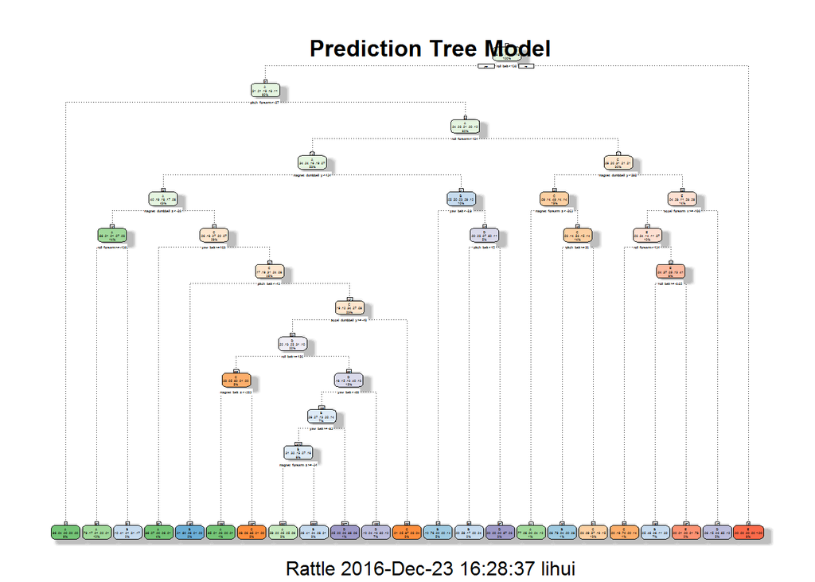

```r
library(rpart)
library(rpart.plot)
library(RColorBrewer)
library(rattle)
treeFit <- rpart(classe ~., data = trainDF)
fancyRpartPlot(treeFit, main = "Prediction Tree Model")
```

- Prediction on test data set

```r
predTree <- predict(treeFit, newdata = testDF, type = "class")
confMtxTree <- confusionMatrix(testDF$classe, predTree)
show(confMtxTree)
```

```
## Confusion Matrix and Statistics
##
##           Reference
## Prediction    A    B    C    D    E
##          A 1007   70   25   63    6
##          B  145  536   72   40    4
##          C   22   80  565   51    0
##          D   33   66  103  458   15
##          E   19  158  117   69  394
##
## Overall Statistics
##
##                Accuracy : 0.7188
##                  95% CI : (0.7048, 0.7325)
##     No Information Rate : 0.2977
##     P-Value [Acc > NIR] : < 2.2e-16
##
##                   Kappa : 0.6438
##  Mcnemar's Test P-Value : < 2.2e-16
##
## Statistics by Class:
##
##                      Class: A Class: B Class: C Class: D Class: E
## Sensitivity            0.8214   0.5890   0.6406   0.6725  0.94033
## Specificity            0.9433   0.9186   0.9527   0.9369  0.90187
## Pos Pred Value         0.8599   0.6725   0.7869   0.6785  0.52048
## Neg Pred Value         0.9257   0.8874   0.9068   0.9352  0.99256
## Prevalence             0.2977   0.2210   0.2142   0.1654  0.10175
## Detection Rate         0.2445   0.1302   0.1372   0.1112  0.09568
## Detection Prevalence   0.2844   0.1935   0.1744   0.1639  0.18383
## Balanced Accuracy      0.8823   0.7538   0.7967   0.8047  0.92110
```

- Prediction on validation data set

```r
predTreeV <- predict(treeFit, newdata = validationDF, type = "class")
confMtxTreeV <- confusionMatrix(validationDF$classe, predTreeV)
show(confMtxTreeV)
```

```
## Confusion Matrix and Statistics
##
##           Reference
## Prediction    A    B    C    D    E
##          A 1477   72   43   77    5
##          B  202  756  114   66    1
##          C   26  113  824   63    0
##          D   56  110  154  625   19
##          E   22  245  142   91  582
##
## Overall Statistics
##
##                Accuracy : 0.7246
##                  95% CI : (0.7129, 0.7359)
##     No Information Rate : 0.303
##     P-Value [Acc > NIR] : < 2.2e-16
##
##                   Kappa : 0.6508
##  Mcnemar's Test P-Value : < 2.2e-16
##
## Statistics by Class:
##
##                      Class: A Class: B Class: C Class: D Class: E
## Sensitivity            0.8284   0.5833   0.6453   0.6779   0.9588
## Specificity            0.9520   0.9165   0.9562   0.9317   0.9053
## Pos Pred Value         0.8823   0.6637   0.8031   0.6483   0.5379
## Neg Pred Value         0.9273   0.8862   0.9068   0.9396   0.9948
## Prevalence             0.3030   0.2202   0.2170   0.1567   0.1031
## Detection Rate         0.2510   0.1285   0.1400   0.1062   0.0989
## Detection Prevalence   0.2845   0.1935   0.1743   0.1638   0.1839
## Balanced Accuracy      0.8902   0.7499   0.8007   0.8048   0.9320
```

## Linear discriminant analysis

- Model fit

```r
library(MASS)
ldaFit <- lda(classe ~., data = trainDF)
```

- Prediction on test data set

```r
predLDA <- predict(ldaFit, newdata = testDF)$class
confMtxLDA <- confusionMatrix(testDF$classe, predLDA)
show(confMtxLDA)
```

```
## Confusion Matrix and Statistics
##
##           Reference
## Prediction   A   B   C   D   E
##          A 939  38 100  88   6
##          B 114 529  64  30  60
##          C  73  63 473  87  22
##          D  35  50  95 464  31
##          E  29 115  64  96 453
##
## Overall Statistics
##
##                Accuracy : 0.694
##                  95% CI : (0.6797, 0.7081)
##     No Information Rate : 0.289
##     P-Value [Acc > NIR] : < 2.2e-16
##
##                   Kappa : 0.6131
##  Mcnemar's Test P-Value : < 2.2e-16
##
## Statistics by Class:
##
##                      Class: A Class: B Class: C Class: D Class: E
## Sensitivity            0.7891   0.6654   0.5942   0.6065   0.7920
## Specificity            0.9208   0.9193   0.9262   0.9371   0.9143
## Pos Pred Value         0.8019   0.6637   0.6588   0.6874   0.5984
## Neg Pred Value         0.9148   0.9199   0.9050   0.9126   0.9646
## Prevalence             0.2890   0.1931   0.1933   0.1858   0.1389
## Detection Rate         0.2280   0.1285   0.1149   0.1127   0.1100
## Detection Prevalence   0.2844   0.1935   0.1744   0.1639   0.1838
## Balanced Accuracy      0.8549   0.7924   0.7602   0.7718   0.8531
```

- Prediction on validation data set

```r
predLDAV <- predict(ldaFit, newdata = validationDF)$class
confMtxLDAV <- confusionMatrix(validationDF$classe, predLDAV)
show(confMtxLDAV)
```

```
## Confusion Matrix and Statistics
##
##           Reference
## Prediction    A    B    C    D    E
##          A 1353   61  156   92   12
##          B  183  726  130   44   56
##          C   86  101  691  127   21
##          D   68   76  110  673   37
##          E   48  176   90  124  644
##
## Overall Statistics
##
##                Accuracy : 0.6945
##                  95% CI : (0.6825, 0.7062)
##     No Information Rate : 0.2953
##     P-Value [Acc > NIR] : < 2.2e-16
##
##                   Kappa : 0.6133
##  Mcnemar's Test P-Value : < 2.2e-16
##
## Statistics by Class:
##
##                      Class: A Class: B Class: C Class: D Class: E
## Sensitivity            0.7785   0.6368   0.5871   0.6349   0.8364
## Specificity            0.9226   0.9130   0.9288   0.9397   0.9144
## Pos Pred Value         0.8082   0.6374   0.6735   0.6981   0.5952
## Neg Pred Value         0.9086   0.9128   0.9000   0.9214   0.9738
## Prevalence             0.2953   0.1937   0.2000   0.1801   0.1308
## Detection Rate         0.2299   0.1234   0.1174   0.1144   0.1094
## Detection Prevalence   0.2845   0.1935   0.1743   0.1638   0.1839
## Balanced Accuracy      0.8505   0.7749   0.7580   0.7873   0.8754
```

## Random forest

- Model fit

```r
library(randomForest)
set.seed(1000)
randForestFit <- randomForest(classe ~., data = trainDF,method="class", ntree = 1000)
show(randForestFit$ntree)
```

```
## [1] 1000
```

- Prediction on test data set

```r
predRandForest <- predict(randForestFit, newdata = testDF)
confMtxRF <- confusionMatrix(testDF$classe, predRandForest)
show(confMtxRF)
```

```
## Confusion Matrix and Statistics
##
##           Reference
## Prediction    A    B    C    D    E
##          A 1171    0    0    0    0
##          B    6  789    2    0    0
##          C    0   12  703    3    0
##          D    0    0   12  662    1
##          E    0    0    2    2  753
##
## Overall Statistics
##
##                Accuracy : 0.9903
##                  95% CI : (0.9868, 0.9931)
##     No Information Rate : 0.2858
##     P-Value [Acc > NIR] : < 2.2e-16
##
##                   Kappa : 0.9877
##  Mcnemar's Test P-Value : NA
##
## Statistics by Class:
##
##                      Class: A Class: B Class: C Class: D Class: E
## Sensitivity            0.9949   0.9850   0.9777   0.9925   0.9987
## Specificity            1.0000   0.9976   0.9956   0.9962   0.9988
## Pos Pred Value         1.0000   0.9900   0.9791   0.9807   0.9947
## Neg Pred Value         0.9980   0.9964   0.9953   0.9985   0.9997
## Prevalence             0.2858   0.1945   0.1746   0.1620   0.1831
## Detection Rate         0.2844   0.1916   0.1707   0.1608   0.1829
## Detection Prevalence   0.2844   0.1935   0.1744   0.1639   0.1838
## Balanced Accuracy      0.9975   0.9913   0.9867   0.9944   0.9987
```

- Prediction on validation data set

```r
predRandForestV <- predict(randForestFit, newdata = validationDF)
confMtxRFV <- confusionMatrix(validationDF$classe, predRandForestV)
show(confMtxRFV)
```

```
## Confusion Matrix and Statistics
##
##           Reference
## Prediction    A    B    C    D    E
##          A 1671    3    0    0    0
##          B    7 1125    7    0    0
##          C    0   16 1006    4    0
##          D    0    0   16  948    0
##          E    0    0    1    2 1079
##
## Overall Statistics
##
##                Accuracy : 0.9905
##                  95% CI : (0.9877, 0.9928)
##     No Information Rate : 0.2851
##     P-Value [Acc > NIR] : < 2.2e-16
##
##                   Kappa : 0.988
##  Mcnemar's Test P-Value : NA
##
## Statistics by Class:
##
##                      Class: A Class: B Class: C Class: D Class: E
## Sensitivity            0.9958   0.9834   0.9767   0.9937   1.0000
## Specificity            0.9993   0.9970   0.9959   0.9968   0.9994
## Pos Pred Value         0.9982   0.9877   0.9805   0.9834   0.9972
## Neg Pred Value         0.9983   0.9960   0.9951   0.9988   1.0000
## Prevalence             0.2851   0.1944   0.1750   0.1621   0.1833
## Detection Rate         0.2839   0.1912   0.1709   0.1611   0.1833
## Detection Prevalence   0.2845   0.1935   0.1743   0.1638   0.1839
## Balanced Accuracy      0.9976   0.9902   0.9863   0.9952   0.9997
```

## Bagging

- Prediction on testing data set

```r
predBagging <- predict(baggingFit, newdata = testDF)
confMtxBagging <- confusionMatrix(testDF$classe, predBagging)
show(confMtxBagging)
```

```
## Confusion Matrix and Statistics
##
##           Reference
## Prediction    A    B    C    D    E
##          A 1167    1    0    2    1
##          B   14  775    5    2    1
##          C    0    9  701    8    0
##          D    1    3   19  651    1
##          E    0    1    4    5  747
##
## Overall Statistics
##
##                Accuracy : 0.9813
##                  95% CI : (0.9767, 0.9852)
##     No Information Rate : 0.287
##     P-Value [Acc > NIR] : < 2.2e-16
##
##                   Kappa : 0.9763
##  Mcnemar's Test P-Value : NA
##
## Statistics by Class:
##
##                      Class: A Class: B Class: C Class: D Class: E
## Sensitivity            0.9873   0.9823   0.9616   0.9746   0.9960
## Specificity            0.9986   0.9934   0.9950   0.9930   0.9970
## Pos Pred Value         0.9966   0.9724   0.9763   0.9644   0.9868
## Neg Pred Value         0.9949   0.9958   0.9918   0.9951   0.9991
## Prevalence             0.2870   0.1916   0.1770   0.1622   0.1821
## Detection Rate         0.2834   0.1882   0.1702   0.1581   0.1814
## Detection Prevalence   0.2844   0.1935   0.1744   0.1639   0.1838
## Balanced Accuracy      0.9930   0.9878   0.9783   0.9838   0.9965
```

- Prediction on validation data set

```r
predBaggingV <- predict(baggingFit, newdata = validationDF)
confMtxBaggingV <- confusionMatrix(validationDF$classe, predBaggingV)
show(confMtxBaggingV)
```

```
## Confusion Matrix and Statistics
##
##           Reference
## Prediction    A    B    C    D    E
##          A 1667    7    0    0    0
##          B   21 1103    8    6    1
##          C    0   10 1001   13    2
##          D    0    2   24  938    0
##          E    0    1    5    4 1072
##
## Overall Statistics
##
##                Accuracy : 0.9823
##                  95% CI : (0.9786, 0.9855)
##     No Information Rate : 0.2868
##     P-Value [Acc > NIR] : < 2.2e-16
##
##                   Kappa : 0.9776
##  Mcnemar's Test P-Value : NA
##
## Statistics by Class:
##
##                      Class: A Class: B Class: C Class: D Class: E
## Sensitivity            0.9876   0.9822   0.9644   0.9761   0.9972
## Specificity            0.9983   0.9924   0.9948   0.9947   0.9979
## Pos Pred Value         0.9958   0.9684   0.9756   0.9730   0.9908
## Neg Pred Value         0.9950   0.9958   0.9924   0.9953   0.9994
## Prevalence             0.2868   0.1908   0.1764   0.1633   0.1827
## Detection Rate         0.2833   0.1874   0.1701   0.1594   0.1822
## Detection Prevalence   0.2845   0.1935   0.1743   0.1638   0.1839
## Balanced Accuracy      0.9929   0.9873   0.9796   0.9854   0.9976
```

## Combining classifiers via random forest

- Fit the combined classifier model on test data set

```r
cNames <- c("RF","BAGGING","TREE",
            "LDA")
combTestDF <- data.frame(predRandForest,predBagging,  predTree,
                         predLDA, testDF$classe)
colnames(combTestDF) <- c(cNames,"classe")
combRfFit <- randomForest(classe~., data = combTestDF, method = "class")
combRfPred <- predict(combRfFit, combTestDF)
confMtxCombRf <- confusionMatrix(testDF$classe,combRfPred)
show(confMtxCombRf)
```

```
## Confusion Matrix and Statistics
##
##           Reference
## Prediction    A    B    C    D    E
##          A 1171    0    0    0    0
##          B    6  789    2    0    0
##          C    0    8  707    3    0
##          D    0    0   11  663    1
##          E    0    0    2    1  754
##
## Overall Statistics
##
##                Accuracy : 0.9917
##                  95% CI : (0.9885, 0.9943)
##     No Information Rate : 0.2858
##     P-Value [Acc > NIR] : < 2.2e-16
##
##                   Kappa : 0.9896
##  Mcnemar's Test P-Value : NA
##
## Statistics by Class:
##
##                      Class: A Class: B Class: C Class: D Class: E
## Sensitivity            0.9949   0.9900   0.9792   0.9940   0.9987
## Specificity            1.0000   0.9976   0.9968   0.9965   0.9991
## Pos Pred Value         1.0000   0.9900   0.9847   0.9822   0.9960
## Neg Pred Value         0.9980   0.9976   0.9956   0.9988   0.9997
## Prevalence             0.2858   0.1935   0.1753   0.1620   0.1833
## Detection Rate         0.2844   0.1916   0.1717   0.1610   0.1831
## Detection Prevalence   0.2844   0.1935   0.1744   0.1639   0.1838
## Balanced Accuracy      0.9975   0.9938   0.9880   0.9953   0.9989
```

- Make prediction on validation data set

```r
combValDF <- data.frame(predRandForestV,predBaggingV, predTreeV, predLDAV)
colnames(combValDF) <- cNames
combRfPredV <- predict(combRfFit, newdata = combValDF, type = "class")
confMtxCombRfV <- confusionMatrix(validationDF$classe,combRfPredV)
show(confMtxCombRfV)
```

```
## Confusion Matrix and Statistics
##
##           Reference
## Prediction    A    B    C    D    E
##          A 1671    3    0    0    0
##          B    7 1124    8    0    0
##          C    0   10 1012    4    0
##          D    0    0   14  950    0
##          E    0    0    1    2 1079
##
## Overall Statistics
##
##                Accuracy : 0.9917
##                  95% CI : (0.989, 0.9938)
##     No Information Rate : 0.2851
##     P-Value [Acc > NIR] : < 2.2e-16
##
##                   Kappa : 0.9895
##  Mcnemar's Test P-Value : NA
##
## Statistics by Class:
##
##                      Class: A Class: B Class: C Class: D Class: E
## Sensitivity            0.9958   0.9886   0.9778   0.9937   1.0000
## Specificity            0.9993   0.9968   0.9971   0.9972   0.9994
## Pos Pred Value         0.9982   0.9868   0.9864   0.9855   0.9972
## Neg Pred Value         0.9983   0.9973   0.9953   0.9988   1.0000
## Prevalence             0.2851   0.1932   0.1759   0.1624   0.1833
## Detection Rate         0.2839   0.1910   0.1720   0.1614   0.1833
## Detection Prevalence   0.2845   0.1935   0.1743   0.1638   0.1839
## Balanced Accuracy      0.9976   0.9927   0.9874   0.9954   0.9997
```

## Appendix 1: other machine learning algorithms

### Regression Model

Regression model is not applicable because the dependent variable “classe” is a 5-level factor variable, while regression model requires the dependent variable be numerical or binary.

### Boosting

```r
numToLet <- function(x){
  if(x == 1) return("A")
  if(x == 2) return("B")
  if(x == 3) return("C")
  if(x == 4) return("D")
  else return("E")
}

library(gbm)
library(survival)
boostingFit <- gbm(classe ~.,  data = trainDF, distribution="multinomial")
predBoosting <- data.frame(predict(boostingFit, newdata = testDF, n.trees = boostingFit$n.trees))
predBoosting <- apply(predBoosting,1,which.max)
predBoosting <- factor(sapply(predBoosting,numToLet))
confMtxBoosting <- confusionMatrix(testDF$classe, predBoosting)
show(confMtxBoosting)
```

```
## Confusion Matrix and Statistics
##
##           Reference
## Prediction   A   B   C   D   E
##          A 533   4 312 308  14
##          B 179 244 221 153   0
##          C 109  15 484 110   0
##          D  73  29 221 352   0
##          E  92 106 147  47 365
##
## Overall Statistics
##
##                Accuracy : 0.4803
##                  95% CI : (0.465, 0.4957)
##     No Information Rate : 0.3363
##     P-Value [Acc > NIR] : < 2.2e-16
##
##                   Kappa : 0.3496
##  Mcnemar's Test P-Value : < 2.2e-16
##
## Statistics by Class:
##
##                      Class: A Class: B Class: C Class: D Class: E
## Sensitivity            0.5406  0.61307   0.3495  0.36289  0.96306
## Specificity            0.7963  0.85134   0.9144  0.89740  0.89516
## Pos Pred Value         0.4552  0.30615   0.6741  0.52148  0.48217
## Neg Pred Value         0.8463  0.95363   0.7350  0.82051  0.99583
## Prevalence             0.2394  0.09665   0.3363  0.23555  0.09203
## Detection Rate         0.1294  0.05925   0.1175  0.08548  0.08864
## Detection Prevalence   0.2844  0.19354   0.1744  0.16391  0.18383
## Balanced Accuracy      0.6684  0.73220   0.6319  0.63014  0.92911
```

### Naive Bayes

```r
nbFit <- naiveBayes(classe ~., data = trainDF)
predNB <- predict(nbFit, newdata = testDF)
confMtxNB <- confusionMatrix(testDF$classe, predNB)
show(confMtxNB)
```

```
## Confusion Matrix and Statistics
##
##           Reference
## Prediction   A   B   C   D   E
##          A 226 135 626 139  45
##          B  24 507 156  41  69
##          C  13  96 481  83  45
##          D   0  18 236 339  82
##          E   5 139 102 118 393
##
## Overall Statistics
##
##                Accuracy : 0.4726
##                  95% CI : (0.4572, 0.4879)
##     No Information Rate : 0.3888
##     P-Value [Acc > NIR] : < 2.2e-16
##
##                   Kappa : 0.3526
##  Mcnemar's Test P-Value : < 2.2e-16
##
## Statistics by Class:
##
##                      Class: A Class: B Class: C Class: D Class: E
## Sensitivity           0.84328   0.5665   0.3004  0.47083  0.61987
## Specificity           0.75455   0.9100   0.9058  0.90112  0.89552
## Pos Pred Value        0.19300   0.6361   0.6699  0.50222  0.51915
## Neg Pred Value        0.98575   0.8832   0.6706  0.88934  0.92830
## Prevalence            0.06508   0.2173   0.3888  0.17484  0.15396
## Detection Rate        0.05488   0.1231   0.1168  0.08232  0.09543
## Detection Prevalence  0.28436   0.1935   0.1744  0.16391  0.18383
## Balanced Accuracy     0.79891   0.7383   0.6031  0.68598  0.75770
```

## Appendix 2: Tree number in the radom forest model

### ntree = 1

- Model fit

```r
library(randomForest)
set.seed(1000)
randForestFit1 <- randomForest(classe ~., data = trainDF,method="class", ntree = 1)
show(randForestFit1$ntree)
```

```
## [1] 1
```

- Prediction on test data set

```r
predRandForest1 <- predict(randForestFit1, newdata = testDF)
confMtxRF1 <- confusionMatrix(testDF$classe, predRandForest1)
show(confMtxRF1)
```

```
## Confusion Matrix and Statistics
##
##           Reference
## Prediction    A    B    C    D    E
##          A 1079   31   25   17   19
##          B   39  657   44   16   41
##          C   27   53  576   44   18
##          D   22   27   49  564   13
##          E    7   31   34   18  667
##
## Overall Statistics
##
##                Accuracy : 0.8604
##                  95% CI : (0.8494, 0.8708)
##     No Information Rate : 0.2851
##     P-Value [Acc > NIR] : < 2e-16
##
##                   Kappa : 0.8234
##  Mcnemar's Test P-Value : 0.05157
##
## Statistics by Class:
##
##                      Class: A Class: B Class: C Class: D Class: E
## Sensitivity            0.9191   0.8223   0.7912   0.8558   0.8799
## Specificity            0.9688   0.9578   0.9581   0.9679   0.9732
## Pos Pred Value         0.9214   0.8243   0.8022   0.8356   0.8811
## Neg Pred Value         0.9678   0.9572   0.9553   0.9724   0.9729
## Prevalence             0.2851   0.1940   0.1768   0.1600   0.1841
## Detection Rate         0.2620   0.1595   0.1399   0.1370   0.1620
## Detection Prevalence   0.2844   0.1935   0.1744   0.1639   0.1838
## Balanced Accuracy      0.9439   0.8900   0.8747   0.9119   0.9266
```

- Prediction on validation data set

```r
predRandForestV1 <- predict(randForestFit1, newdata = validationDF)
confMtxRFV1 <- confusionMatrix(validationDF$classe, predRandForestV1)
show(confMtxRFV1)
```

```
## Confusion Matrix and Statistics
##
##           Reference
## Prediction    A    B    C    D    E
##          A 1549   48   39   17   21
##          B   54  932   62   36   55
##          C   37   59  861   36   33
##          D   43   21   67  811   22
##          E   11   42   48   29  952
##
## Overall Statistics
##
##                Accuracy : 0.8675
##                  95% CI : (0.8585, 0.876)
##     No Information Rate : 0.2879
##     P-Value [Acc > NIR] : < 2.2e-16
##
##                   Kappa : 0.8323
##  Mcnemar's Test P-Value : 0.0002133
##
## Statistics by Class:
##
##                      Class: A Class: B Class: C Class: D Class: E
## Sensitivity            0.9144   0.8457   0.7994   0.8730   0.8790
## Specificity            0.9702   0.9567   0.9657   0.9691   0.9729
## Pos Pred Value         0.9253   0.8183   0.8392   0.8413   0.8799
## Neg Pred Value         0.9656   0.9642   0.9555   0.9760   0.9727
## Prevalence             0.2879   0.1873   0.1830   0.1579   0.1840
## Detection Rate         0.2632   0.1584   0.1463   0.1378   0.1618
## Detection Prevalence   0.2845   0.1935   0.1743   0.1638   0.1839
## Balanced Accuracy      0.9423   0.9012   0.8826   0.9211   0.9260
```

### ntree = 10

- Model fit

```r
library(randomForest)
set.seed(1000)
randForestFit10 <- randomForest(classe ~., data = trainDF,method="class", ntree = 10)
show(randForestFit10$ntree)
```

```
## [1] 10
```

- Prediction on test data set

```r
predRandForest10 <- predict(randForestFit10, newdata = testDF)
confMtxRF10 <- confusionMatrix(testDF$classe, predRandForest10)
show(confMtxRF10)
```

```
## Confusion Matrix and Statistics
##
##           Reference
## Prediction    A    B    C    D    E
##          A 1164    2    2    2    1
##          B    6  784    4    0    3
##          C    0   16  700    2    0
##          D    0    0   28  646    1
##          E    0    0    1    6  750
##
## Overall Statistics
##
##                Accuracy : 0.982
##                  95% CI : (0.9775, 0.9859)
##     No Information Rate : 0.2841
##     P-Value [Acc > NIR] : < 2.2e-16
##
##                   Kappa : 0.9773
##  Mcnemar's Test P-Value : NA
##
## Statistics by Class:
##
##                      Class: A Class: B Class: C Class: D Class: E
## Sensitivity            0.9949   0.9776   0.9524   0.9848   0.9934
## Specificity            0.9976   0.9961   0.9947   0.9916   0.9979
## Pos Pred Value         0.9940   0.9837   0.9749   0.9570   0.9908
## Neg Pred Value         0.9980   0.9946   0.9897   0.9971   0.9985
## Prevalence             0.2841   0.1948   0.1785   0.1593   0.1833
## Detection Rate         0.2827   0.1904   0.1700   0.1569   0.1821
## Detection Prevalence   0.2844   0.1935   0.1744   0.1639   0.1838
## Balanced Accuracy      0.9962   0.9868   0.9735   0.9882   0.9956
```

- Prediction on validation data set

```r
predRandForestV10 <- predict(randForestFit10, newdata = validationDF)
confMtxRFV10 <- confusionMatrix(validationDF$classe, predRandForestV10)
show(confMtxRFV10)
```

```
## Confusion Matrix and Statistics
##
##           Reference
## Prediction    A    B    C    D    E
##          A 1669    4    0    1    0
##          B   18 1104   13    1    3
##          C    1   27  992    6    0
##          D    4    3   30  926    1
##          E    0    2    3    4 1073
##
## Overall Statistics
##
##                Accuracy : 0.9794
##                  95% CI : (0.9755, 0.9829)
##     No Information Rate : 0.2875
##     P-Value [Acc > NIR] : < 2.2e-16
##
##                   Kappa : 0.974
##  Mcnemar's Test P-Value : NA
##
## Statistics by Class:
##
##                      Class: A Class: B Class: C Class: D Class: E
## Sensitivity            0.9864   0.9684   0.9557   0.9872   0.9963
## Specificity            0.9988   0.9926   0.9930   0.9923   0.9981
## Pos Pred Value         0.9970   0.9693   0.9669   0.9606   0.9917
## Neg Pred Value         0.9945   0.9924   0.9905   0.9976   0.9992
## Prevalence             0.2875   0.1937   0.1764   0.1594   0.1830
## Detection Rate         0.2836   0.1876   0.1686   0.1573   0.1823
## Detection Prevalence   0.2845   0.1935   0.1743   0.1638   0.1839
## Balanced Accuracy      0.9926   0.9805   0.9743   0.9898   0.9972
```

### ntree = 100

- Model fit

```r
library(randomForest)
set.seed(1000)
randForestFit100 <- randomForest(classe ~., data = trainDF,method="class", ntree = 100)
show(randForestFit100$ntree)
```

```
## [1] 100
```

- Prediction on test data set

```r
predRandForest100 <- predict(randForestFit100, newdata = testDF)
confMtxRF100 <- confusionMatrix(testDF$classe, predRandForest100)
show(confMtxRF100)
```

```
## Confusion Matrix and Statistics
##
##           Reference
## Prediction    A    B    C    D    E
##          A 1171    0    0    0    0
##          B    7  788    2    0    0
##          C    0   10  706    2    0
##          D    0    0   17  657    1
##          E    0    0    1    2  754
##
## Overall Statistics
##
##                Accuracy : 0.9898
##                  95% CI : (0.9862, 0.9926)
##     No Information Rate : 0.2861
##     P-Value [Acc > NIR] : < 2.2e-16
##
##                   Kappa : 0.9871
##  Mcnemar's Test P-Value : NA
##
## Statistics by Class:
##
##                      Class: A Class: B Class: C Class: D Class: E
## Sensitivity            0.9941   0.9875   0.9725   0.9939   0.9987
## Specificity            1.0000   0.9973   0.9965   0.9948   0.9991
## Pos Pred Value         1.0000   0.9887   0.9833   0.9733   0.9960
## Neg Pred Value         0.9976   0.9970   0.9941   0.9988   0.9997
## Prevalence             0.2861   0.1938   0.1763   0.1605   0.1833
## Detection Rate         0.2844   0.1914   0.1714   0.1595   0.1831
## Detection Prevalence   0.2844   0.1935   0.1744   0.1639   0.1838
## Balanced Accuracy      0.9970   0.9924   0.9845   0.9944   0.9989
```

- Prediction on validation data set

```r
predRandForestV100 <- predict(randForestFit100, newdata = validationDF)
confMtxRFV100 <- confusionMatrix(validationDF$classe, predRandForestV100)
show(confMtxRFV100)
```

```
## Confusion Matrix and Statistics
##
##           Reference
## Prediction    A    B    C    D    E
##          A 1670    4    0    0    0
##          B    7 1124    8    0    0
##          C    0   16 1007    3    0
##          D    0    0   21  943    0
##          E    0    0    1    4 1077
##
## Overall Statistics
##
##                Accuracy : 0.9891
##                  95% CI : (0.9861, 0.9916)
##     No Information Rate : 0.285
##     P-Value [Acc > NIR] : < 2.2e-16
##
##                   Kappa : 0.9862
##  Mcnemar's Test P-Value : NA
##
## Statistics by Class:
##
##                      Class: A Class: B Class: C Class: D Class: E
## Sensitivity            0.9958   0.9825   0.9711   0.9926   1.0000
## Specificity            0.9990   0.9968   0.9961   0.9957   0.9990
## Pos Pred Value         0.9976   0.9868   0.9815   0.9782   0.9954
## Neg Pred Value         0.9983   0.9958   0.9938   0.9986   1.0000
## Prevalence             0.2850   0.1944   0.1762   0.1614   0.1830
## Detection Rate         0.2838   0.1910   0.1711   0.1602   0.1830
## Detection Prevalence   0.2845   0.1935   0.1743   0.1638   0.1839
## Balanced Accuracy      0.9974   0.9897   0.9836   0.9942   0.9995
```

### ntree = 1000

- Model fit

```r
library(randomForest)
set.seed(1000)
randForestFit1000 <- randomForest(classe ~., data = trainDF,method="class", ntree = 1000)
show(randForestFit1000$ntree)
```

```
## [1] 1000
```

- Prediction on test data set

```r
predRandForest1000 <- predict(randForestFit1000, newdata = testDF)
confMtxRF1000 <- confusionMatrix(testDF$classe, predRandForest1000)
show(confMtxRF1000)
```

```
## Confusion Matrix and Statistics
##
##           Reference
## Prediction    A    B    C    D    E
##          A 1171    0    0    0    0
##          B    6  789    2    0    0
##          C    0   12  703    3    0
##          D    0    0   12  662    1
##          E    0    0    2    2  753
##
## Overall Statistics
##
##                Accuracy : 0.9903
##                  95% CI : (0.9868, 0.9931)
##     No Information Rate : 0.2858
##     P-Value [Acc > NIR] : < 2.2e-16
##
##                   Kappa : 0.9877
##  Mcnemar's Test P-Value : NA
##
## Statistics by Class:
##
##                      Class: A Class: B Class: C Class: D Class: E
## Sensitivity            0.9949   0.9850   0.9777   0.9925   0.9987
## Specificity            1.0000   0.9976   0.9956   0.9962   0.9988
## Pos Pred Value         1.0000   0.9900   0.9791   0.9807   0.9947
## Neg Pred Value         0.9980   0.9964   0.9953   0.9985   0.9997
## Prevalence             0.2858   0.1945   0.1746   0.1620   0.1831
## Detection Rate         0.2844   0.1916   0.1707   0.1608   0.1829
## Detection Prevalence   0.2844   0.1935   0.1744   0.1639   0.1838
## Balanced Accuracy      0.9975   0.9913   0.9867   0.9944   0.9987
```

- Prediction on validation data set

```r
predRandForestV1000 <- predict(randForestFit1000, newdata = validationDF)
confMtxRFV1000 <- confusionMatrix(validationDF$classe, predRandForestV1000)
show(confMtxRFV1000)
```

```
## Confusion Matrix and Statistics
##
##           Reference
## Prediction    A    B    C    D    E
##          A 1671    3    0    0    0
##          B    7 1125    7    0    0
##          C    0   16 1006    4    0
##          D    0    0   16  948    0
##          E    0    0    1    2 1079
##
## Overall Statistics
##
##                Accuracy : 0.9905
##                  95% CI : (0.9877, 0.9928)
##     No Information Rate : 0.2851
##     P-Value [Acc > NIR] : < 2.2e-16
##
##                   Kappa : 0.988
##  Mcnemar's Test P-Value : NA
##
## Statistics by Class:
##
##                      Class: A Class: B Class: C Class: D Class: E
## Sensitivity            0.9958   0.9834   0.9767   0.9937   1.0000
## Specificity            0.9993   0.9970   0.9959   0.9968   0.9994
## Pos Pred Value         0.9982   0.9877   0.9805   0.9834   0.9972
## Neg Pred Value         0.9983   0.9960   0.9951   0.9988   1.0000
## Prevalence             0.2851   0.1944   0.1750   0.1621   0.1833
## Detection Rate         0.2839   0.1912   0.1709   0.1611   0.1833
## Detection Prevalence   0.2845   0.1935   0.1743   0.1638   0.1839
## Balanced Accuracy      0.9976   0.9902   0.9863   0.9952   0.9997
```

## Appendix 3: Combining classifiers via decision tree

```r
library(rpart)
combTreeFit <- rpart(classe~., data = combTestDF, method = "class")
combTreePred <- predict(combTreeFit, combTestDF,type = "class")
confMtxCombTree <- confusionMatrix(testDF$classe,combTreePred)
show(confMtxCombTree)
```

```
## Confusion Matrix and Statistics
##
##           Reference
## Prediction    A    B    C    D    E
##          A 1171    0    0    0    0
##          B    6  789    2    0    0
##          C    0   12  703    3    0
##          D    0    0   12  662    1
##          E    0    0    2    2  753
##
## Overall Statistics
##
##                Accuracy : 0.9903
##                  95% CI : (0.9868, 0.9931)
##     No Information Rate : 0.2858
##     P-Value [Acc > NIR] : < 2.2e-16
##
##                   Kappa : 0.9877
##  Mcnemar's Test P-Value : NA
##
## Statistics by Class:
##
##                      Class: A Class: B Class: C Class: D Class: E
## Sensitivity            0.9949   0.9850   0.9777   0.9925   0.9987
## Specificity            1.0000   0.9976   0.9956   0.9962   0.9988
## Pos Pred Value         1.0000   0.9900   0.9791   0.9807   0.9947
## Neg Pred Value         0.9980   0.9964   0.9953   0.9985   0.9997
## Prevalence             0.2858   0.1945   0.1746   0.1620   0.1831
## Detection Rate         0.2844   0.1916   0.1707   0.1608   0.1829
## Detection Prevalence   0.2844   0.1935   0.1744   0.1639   0.1838
## Balanced Accuracy      0.9975   0.9913   0.9867   0.9944   0.9987
```

```r
combTreePredV <- predict(combTreeFit, newdata = combValDF, type = "class")
confMtxCombTreeV <- confusionMatrix(validationDF$classe, combTreePredV)
show(confMtxCombTreeV)
```

```
## Confusion Matrix and Statistics
##
##           Reference
## Prediction    A    B    C    D    E
##          A 1671    3    0    0    0
##          B    7 1125    7    0    0
##          C    0   16 1006    4    0
##          D    0    0   16  948    0
##          E    0    0    1    2 1079
##
## Overall Statistics
##
##                Accuracy : 0.9905
##                  95% CI : (0.9877, 0.9928)
##     No Information Rate : 0.2851
##     P-Value [Acc > NIR] : < 2.2e-16
##
##                   Kappa : 0.988
##  Mcnemar's Test P-Value : NA
##
## Statistics by Class:
##
##                      Class: A Class: B Class: C Class: D Class: E
## Sensitivity            0.9958   0.9834   0.9767   0.9937   1.0000
## Specificity            0.9993   0.9970   0.9959   0.9968   0.9994
## Pos Pred Value         0.9982   0.9877   0.9805   0.9834   0.9972
## Neg Pred Value         0.9983   0.9960   0.9951   0.9988   1.0000
## Prevalence             0.2851   0.1944   0.1750   0.1621   0.1833
## Detection Rate         0.2839   0.1912   0.1709   0.1611   0.1833
## Detection Prevalence   0.2845   0.1935   0.1743   0.1638   0.1839
## Balanced Accuracy      0.9976   0.9902   0.9863   0.9952   0.9997
```